# Операционные системы

Установка и конфигурация операционной системы на виртуальную машину

Имад Акрур

Российский университет дружбы народов, Москва, Россия

06.03.2025

# Информация

## Докладчик

- Имад Акрур
- НКАбд-01-24 , студ билет № 1032239342
- Российский университет дружбы народов
- 1032239342@pfur.ru
- https://github.com/imadakrour/study_2024-2025_os-intro

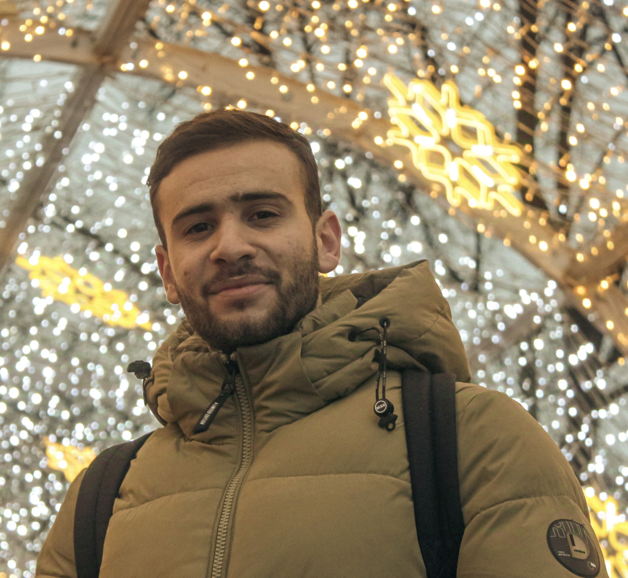

# Цель работы

- Целью данной работы является приобретение практических навыков установки операционной системы на виртуальную машину, настройки минимально необходимых для дальнейшей работы сервисов.

# Материалы и методы

- VirtualBox 7.0.6
- Fedora Linux 41.

# Ход работы:

## Конфигурация virtualbox:

- Прежде всего мы настраиваем имя виртуальной машины и выбираем тип и версию нашего дистрибутива.
- Настройка объема оперативной памяти с 2048 МБ (в нашем случае 3084 МБ)
- Задаём конфигурацию жесткого диска– VDI (VirtualBox Disk Image)

## Конфигурация virtualbox:

- Задаём размер диска от 80 ГБ
- Увеличение доступного объема видеопамяти до 128 МБ
- Во вкладке Носители добавляем новый оптический дисковод и выбираем наш образ Linux-Fedora с компьютера

## Запуск виртуальной машины и начало установки системы :

- Мы выбираем верхний вариант «Start Fedora-workstation-live 36», затем нажимаем “Install to hard drive”.
- Настройка системного языка, языка ввода и времени.
- Выбор диска, на который будем устанавливать нашу операционную систему, затем мы нажимаем начать установку
- Мы ждем окончания установки, затем нажимаем завершить установку.

## Запуск виртуальной машины и начало установки системы :

- после установки мы завершаем сеанс виртуальной машины, удаляем образ диска из дисковода
- Мы запускаем виртуальную машину, в которой мы должны создать нового пользователя (логин пользователя совпадает с логином студента в дисплейном классе) и настройкой пароля.
- На данный момент мы успешно установили операционную систему «Fedora» на виртуальную машину.

## После установки:

- После установки мы обновили все пакеты **dnf**.
- мы установили **tmux** для повышения комфорта при использовании терминала.
- Мы подготовили систему к автоматическому обновлению пакетов с помощью таймера.

## После установки:

- Мы отключили **SELINUX**, потому что он нам не нужен в будущей работе.

```
SELINUX=enforcing
на значение
SELINUX=permissive
```

## После установки:

- Затем мы установили драйверы, необходимые для virtualbox
- затем мы отредактировали способ изменения языка клавиатуры с помощью сочетаний клавиш, используя **правый ctrl**.

## Установка программного обеспечения для создания документации:

- С помощью **tmux** мы установили **pandoc** и необходимые расширения.

```
dnf -y install pandoc
pip install pandoc-fignos pandoc-eqnos pandoc-tablenos pandoc-secnos --user
```

- и, наконец, мы установили texlive

```
dnf -y install texlive texlive-\*
```

# Вывод:

- В этой лабораторной работе мы узнали как установить систему на виртуальную машину как использовать терминал выполнив другую команду для установки необходимых программ для будущей работы.